# Reddit_Analysis

Kyra Brown

2026-06-05

```r
library(tidyverse)
```

```r
library(dplyr)
library(ggplot2)
library(readr)
library(Rtsne)
library(ggrepel)
library(tidyr)
library(stringr)
```

1. Grouping demographics data of participants into high short/long, low short/long, high short low long, and low short high long and comparing across lexical data.

```r
#Loading demographics data
demographics <- read.csv("../Data/cleaned_data/demographics_data.csv")

#Calculates scores for long form (articles, books, newsletters, podcasts, etc) and short form (social media) language exposure for each participant
demographics <- demographics %>% mutate (
  long_form_score = long_NewsArticles + long_FictionBooks + long_NonFictionBooks + long_EssaysBlogsNewsletters + long_Podcasts,
  short_form_score = social_Twitter + social_Facebook + social_TikTok + social_Reddit + social_YouTube + social_Instagram + social_Snapchat
)

#Calculates median scores used to split participants into groups
median_long_form <- median(demographics$long_form_score, na.rm = TRUE) #9
median_short_form <- median(demographics$short_form_score, na.rm = TRUE) #11

#Assigns participants to one of four language exposure groups based on the median in each type of content
demographics <- demographics %>% mutate (
  language_exposure_group = case_when(
    long_form_score < median_long_form & short_form_score < median_short_form ~ "low_long_low_short",
    long_form_score < median_long_form & short_form_score >= median_short_form ~ "low_long_high_short",
    long_form_score >= median_long_form & short_form_score < median_short_form ~ "high_long_low_short",
    long_form_score >= median_long_form & short_form_score >= median_short_form ~ "high_long_high_short",
  )
  )

#Gets count of how many participants fall into every group
demographics %>%
  count(language_exposure_group)
```

```
##   language_exposure_group  n
## 1    high_long_high_short 31
## 2     high_long_low_short 28
## 3     low_long_high_short 25
## 4      low_long_low_short 26
```

```r
#Loads in forager lexical results for each domain and combines them into one dataset
all_lexical_results <- bind_rows(read_csv("forager/output/animals_forager_results/lexical_results.csv") %>%
                                   mutate(domain = "animals", Subject = as.character(Subject)),
                                 read_csv("forager/output/authors_forager_results/lexical_results.csv") %>%
                                   mutate(domain = "authors", Subject = as.character(Subject)),
                                 read_csv("forager/output/college_majors_forager_results/lexical_results.csv") %>%
                                   mutate(domain = "college_majors", Subject = as.character(Subject)),
                                 read_csv("forager/output/musicians_forager_results/lexical_results.csv") %>%
                                   mutate(domain = "musicians", Subject = as.character(Subject)),
                                 read_csv("forager/output/sportspersons_forager_results/lexical_results.csv") %>%
                                   mutate(domain = "sportspersons", Subject = as.character(Subject)),
                                 )
```

```r
#Combines lexical results with demographics results, adding langiage exposure data
lexical_language_exposure_groups <- all_lexical_results %>%
  left_join(demographics %>% select(subject, language_exposure_group), by = c("Subject" = "subject"))

#Removes any participants who weren't matched properly to a language exposure group
lexical_language_exposure_groups <- lexical_language_exposure_groups %>% filter(!is.na(language_exposure_group))

#Calculates the semantic/phonological similarity and word frequency for each domain and language exposure group
lexical_summary <- lexical_language_exposure_groups %>%
  group_by(domain, language_exposure_group) %>%
  summarise(mean_semantic = mean(Semantic_Similarity, na.rm = TRUE),
            mean_phonological = mean(Phonological_Similarity, na.rm = TRUE),
            mean_frequency = mean(Frequency_Value, na.rm = TRUE),
            .groups = "drop")
print(lexical_summary)
```

```
## # A tibble: 20 × 5
##    domain  language_exposure_gr…¹ mean_semantic mean_phonological mean_frequency
##    <chr>   <chr>                          <dbl>             <dbl>          <dbl>
##  1 animals high_long_high_short           0.402            0.0763           3.84
##  2 animals high_long_low_short            0.401            0.0751           3.88
##  3 animals low_long_high_short            0.413            0.0746           3.88
##  4 animals low_long_low_short             0.415            0.0721           3.83
##  5 authors high_long_high_short           0.248            0.0825           3.04
##  6 authors high_long_low_short            0.275            0.0666           2.91
##  7 authors low_long_high_short            0.272            0.0752           3.23
##  8 authors low_long_low_short             0.255            0.0799           2.96
##  9 colleg… high_long_high_short           0.374            0.121            4.45
## 10 colleg… high_long_low_short            0.382            0.118            4.41
## 11 colleg… low_long_high_short            0.385            0.120            4.38
## 12 colleg… low_long_low_short             0.386            0.111            4.45
## 13 musici… high_long_high_short           0.280            0.0747           3.20
## 14 musici… high_long_low_short            0.297            0.0765           3.21
## 15 musici… low_long_high_short            0.290            0.0826           3.29
## 16 musici… low_long_low_short             0.283            0.0693           3.06
## 17 sports… high_long_high_short           0.294            0.0847           3.17
## 18 sports… high_long_low_short            0.263            0.0664           3.16
## 19 sports… low_long_high_short            0.300            0.0835           3.17
## 20 sports… low_long_low_short             0.298            0.0891           2.93
## # ℹ abbreviated name: ¹language_exposure_group
```

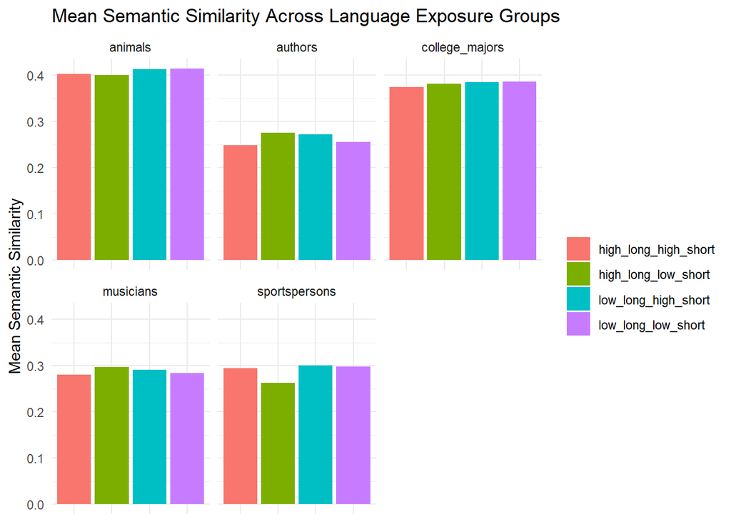

```r
#lexical_analysis_data<-all_items %>%
 # rename("semantic" = "Semantic_Similarity_mean",
  #       "phonological" = "Phonological_Similarity_mean",
 #        "frequency" = "Frequency_Value_mean")%>%
 # pivot_longer(names_to = "cue", cols=c(semantic,phonological,frequency))


#lexical_raw_results


#Plotting semantic similarity across groups
ggplot(lexical_summary, aes(x = language_exposure_group, y = mean_semantic, fill = language_exposure_group)) +
  geom_col() +
  facet_wrap(~ domain) +
  labs(title = "Mean Semantic Similarity Across Language Exposure Groups", x = NULL, y = "Mean Semantic Similarity") +
  theme_minimal() +
  theme(axis.text.x = element_blank(), legend.title = element_blank())
```

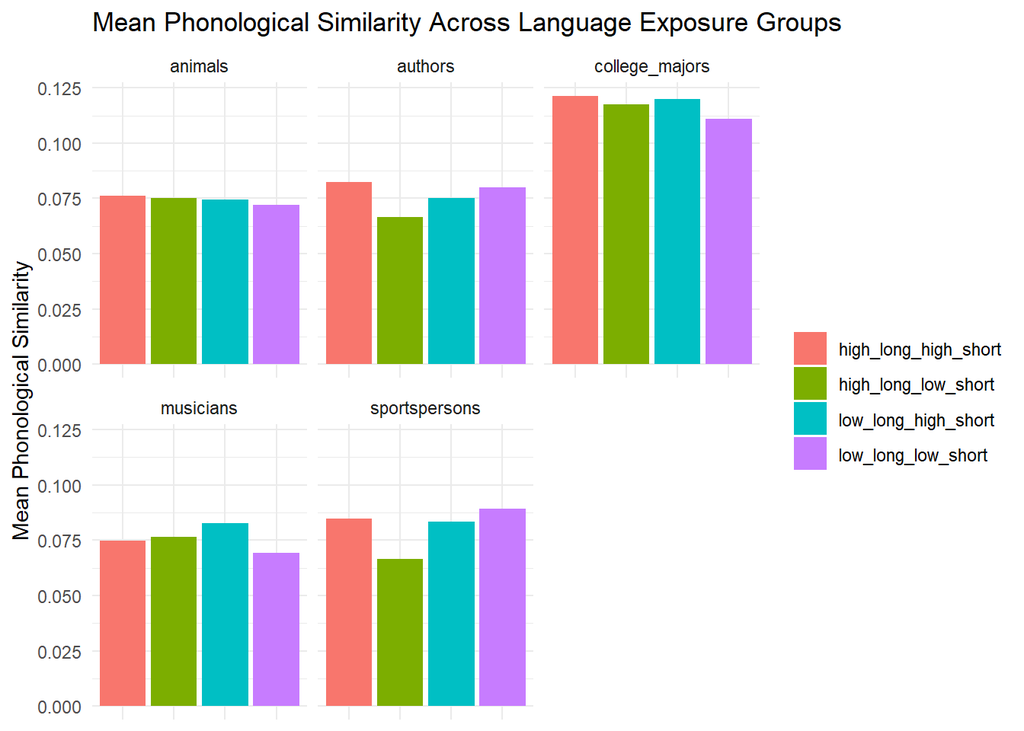

```r
ggsave("semantic_similarity_across_language_exposure.png", width = 8, height = 5, dpi = 300)


#Plotting phonological similarity across groups
ggplot(lexical_summary, aes(x = language_exposure_group, y = mean_phonological, fill = language_exposure_group)) +
  geom_col() +
  facet_wrap(~ domain) +
  labs(title = "Mean Phonological Similarity Across Language Exposure Groups", x = NULL, y = "Mean Phonological Similarity") +
  theme_minimal() +
  theme(axis.text.x = element_blank(), legend.title = element_blank())
```

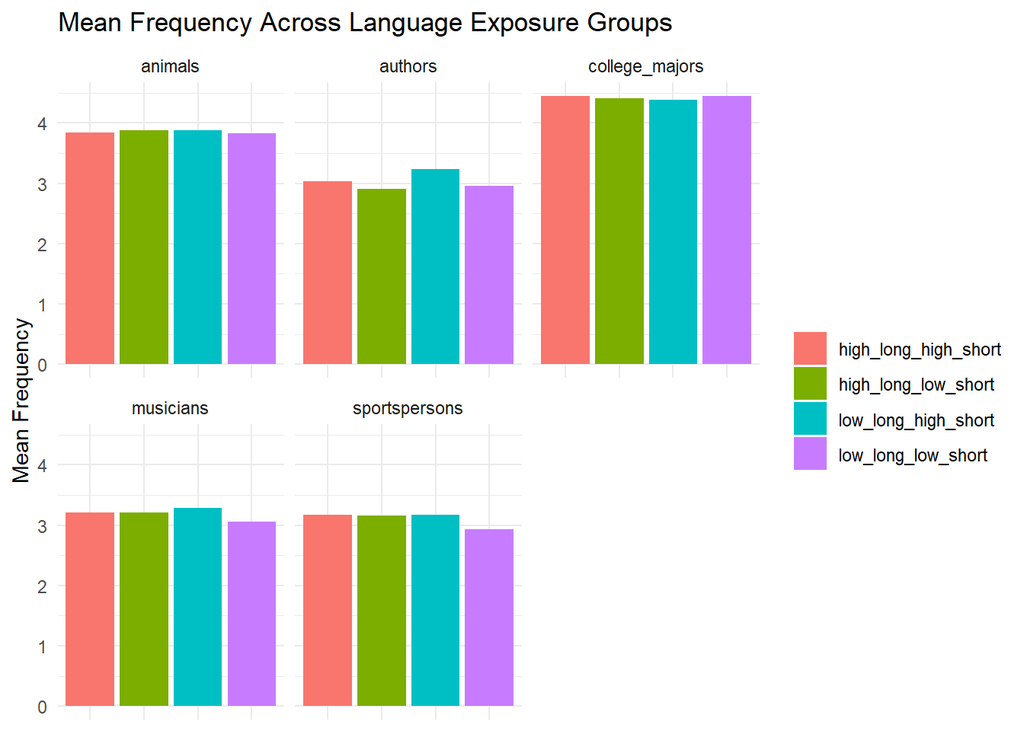

```r
ggsave("phonological_similarity_across_language_exposure.png", width = 8, height = 5, dpi = 300)


#Plotting frequency across groups
ggplot(lexical_summary, aes(x = language_exposure_group, y = mean_frequency, fill = language_exposure_group)) +
  geom_col() +
  facet_wrap(~ domain) +
  labs(title = "Mean Frequency Across Language Exposure Groups", x = NULL, y = "Mean Frequency") +
  theme_minimal() +
  theme(axis.text.x = element_blank(), legend.title = element_blank())
```

```r
ggsave("frequency_across_language_exposure.png", width = 8, height = 5, dpi = 300)
```

```r
subreddit_data <- read_csv("../Data/cleaned_data/subreddit_data.csv")
subreddit_counts <- subreddit_data %>%
  count(corrected_subreddit, sort = TRUE)
View(subreddit_counts)

top_150_subs <- subreddit_data %>%
  count(corrected_subreddit, sort = TRUE) %>%
  head(150)

#subreddit categories manually coded, see "top_150_subs_categorized.csv."

category_map <- read_csv("top_150_subs_categorized.csv")
subreddit_data_categorized <- subreddit_data %>% left_join(category_map, by = "corrected_subreddit")
view(subreddit_data_categorized)

subreddit_data_categorized <- subreddit_data %>% left_join(category_map, by = "corrected_subreddit") %>% left_join(category_map, by = c("alt_subreddit_1" = "corrected_subreddit"), suffix = c("", "_alt")) %>% dplyr::mutate(category = coalesce(category, category_alt)) %>% dplyr::select(-category_alt)
subreddit_data_categorized %>% count(category, sort = TRUE)
```

```
## # A tibble: 11 × 2
##    category                n
##    <chr>               <int>
##  1 <NA>                  243
##  2 entertainment         215
##  3 advice                146
##  4 academic and career    92
##  5 learning               44
##  6 creative               39
##  7 geographic             39
##  8 news                   28
##  9 athletic               25
## 10 food                    4
## 11 religion                4
```

Categorizing Subreddit preferences by participant’s first input

```r
subreddit_data <- read_csv("../Data/cleaned_data/subreddit_data.csv")
subreddit_counts <- subreddit_data %>%
  count(corrected_subreddit, sort = TRUE)
View(subreddit_counts)

top_150_subs <- subreddit_data %>%
  count(corrected_subreddit, sort = TRUE) %>%
  head(150)

category_map <- read_csv("../Analysis/top_150_subs_categorized.csv")
```

```r
manually_added_categories <- tribble(
  ~corrected_subreddit, ~category,
  "r/BPD", "advice",
  "r/Baking", "food",
  "r/Barca", "athletic",
  "r/BostonBruins", "athletic",
  "r/Breath_of_the_Wild", "entertainment",
  "r/Biohackers", "learning",
  "r/BostonBruins", "athletic",
  "r/Buddhism", "religion",
  "r/CFB", "athletic",
  "r/Catholicism", "religion",
  "r/ChatGPT", "learning",
  "r/Costco", "food",
  "r/CozyPlaces", "entertainment",
  "r/CrumblCookies", "food",
  "r/Dreams", "advice",
  "r/EDC", "advice",
  "r/EDH", "entertainment",
  "r/EngagementRings", "creative",
  "r/FigureSkating", "athletic",
  "r/FinancialCareers", "academic and career",
  "r/Forex", "academic and career",
  "r/FundieSnarkUncensored", "religion",
  "r/GaySoundsShitposts", "entertainment",
  "r/GaylorSwift", "entertainment",
  "r/Hair", "creative",
  "r/Handwriting", "creative",
  "r/HomeworkHelp", "academic and career",
  "r/HonkaiStarRail", "entertainment",
  "r/IdiotsInCars", "entertainment",
  "r/Indianapolis", "geographic",
  "r/Jujutsufolk", "entertainment",
  "r/MCFC", "athletic",
  "r/Millennials", "advice",
  "r/Mommit", "advice",
  "r/MurderedByWords", "entertainment",
  "r/NoSleep", "entertainment",
  "r/NonCredibleDefense", "geographic",
  "r/Omaha", "geographic",
  "r/OnePiece", "entertainment",
  "r/Reverse1999", "entertainment",
  "r/RoastMe", "advice",
  "r/StockMarket", "learning",
  "r/UXDesign", "academic and career",
  "r/math", "academic and career",
  "r/clinicalresearch", "academic and career",
  "r/celestegame", "entertainment",
  "r/surfing", "athletic",
  "r/TraderJoes", "food",
  "r/asexuality", "advice",
  "r/apples", "food",
  "r/ftm", "advice",
  "r/uswnt", "athletic",
  "r/sentinelsmultiverse", "entertainment",
  "r/deloitte", "academic and career",
  "r/peloton", "athletic",
  "r/philosophy", "learning",
  "r/vegan", "food",
  "r/rance", "geographic",
  "r/simpleliving", "learning",
  "r/tea", "food",
  "r/whatisthisbird", "learning",
  "r/vexillology", "learning",
  "r/trees", "food",
  "r/foodiesnark", "food"
 )

category_map_complete <- bind_rows(category_map, manually_added_categories)


subreddit_data_categorized <- subreddit_data %>%
  left_join(category_map_complete, by = "corrected_subreddit") %>%
  left_join(category_map_complete, by = c("alt_subreddit_1" = "corrected_subreddit"), suffix = c("", "_alt1")) %>%
  left_join(category_map_complete, by = c("alt_subreddit_2" = "corrected_subreddit"), suffix = c("", "_alt2")) %>%
  mutate(category = coalesce(category, category_alt1, category_alt2)) %>%
  select(-category_alt1, -category_alt2)
view(subreddit_data_categorized)
subreddit_data_categorized %>% count(category, sort = TRUE)
```

```
## # A tibble: 11 × 2
##    category                n
##    <chr>               <int>
##  1 entertainment         272
##  2 advice                168
##  3 academic and career   107
##  4 <NA>                   94
##  5 learning               56
##  6 geographic             47
##  7 creative               46
##  8 athletic               37
##  9 news                   30
## 10 food                   14
## 11 religion                9
```

```r
subreddit_data_categorized <- subreddit_data_categorized %>%
  mutate(category = replace_na(category, "other"))

primary_buckets <- subreddit_data_categorized %>%
  filter(tag == 1) %>%
  transmute(Subject, primary_subreddit = corrected_subreddit, primary_bucket = category)

df_analysis <- subreddit_data_categorized %>%
  left_join(primary_buckets, by = "Subject") %>%
  mutate(matches_primary = (category == primary_bucket))

other_subreddit_alignment_check <- df_analysis %>%
  group_by(Subject, primary_subreddit, primary_bucket) %>%
  summarise(
    total_subreddits = n(),
    matching_category = sum(matches_primary, na.rm = TRUE),
    unknown_category = sum(is.na(category)),
    percentage_match = round(100 * matching_category / total_subreddits, 1),
    mismatched_subreddits = paste(corrected_subreddit[!matches_primary & !is.na(category)], collapse = ", "), .groups = "drop"
  ) %>%
  arrange(desc(percentage_match))

print(other_subreddit_alignment_check, n = Inf)
```

```
## # A tibble: 110 × 8
##     Subject  primary_subreddit primary_bucket total_subreddits matching_category
##     <chr>    <chr>             <chr>                     <int>             <int>
##   1 0PRAW6DO r/gradadmissions  academic and …                1                 1
##   2 476LZI3N r/ApplyingToColl… academic and …                1                 1
##   3 8JEQ20SU r/books           academic and …                1                 1
##   4 B3MZX5TF r/AskReddit       advice                        1                 1
##   5 EA8GWQDV r/running         athletic                      3                 3
##   6 LUKGQM9Q r/gaming          entertainment                 1                 1
##   7 TPWBA9PZ r/medicine        academic and …                3                 3
##   8 U2N1A8VX r/clinicalresear… academic and …                2                 2
##   9 U4TQC9J3 r/all             entertainment                 1                 1
##  10 UIBPJL1Q r/neoliberal      news                          2                 2
##  11 UVAI5SO9 r/cancer          advice                        2                 2
##  12 YP5UHRSA r/AskReddit       advice                        1                 1
```

[output cut: 100 more lines]

```r
category_distribution <- df_analysis %>%
  count(category, sort = TRUE) %>%
  mutate(pct = round(100 * n / sum(n), 1))

print(category_distribution)
```

```
## # A tibble: 11 × 3
##    category                n   pct
##    <chr>               <int> <dbl>
##  1 entertainment         272  30.9
##  2 advice                168  19.1
##  3 academic and career   107  12.2
##  4 other                  94  10.7
##  5 learning               56   6.4
##  6 geographic             47   5.3
##  7 creative               46   5.2
##  8 athletic               37   4.2
##  9 news                   30   3.4
## 10 food                   14   1.6
## 11 religion                9   1
```

```r
subreddit_data_categorized %>%
  filter(is.na(category))%>%
  count(corrected_subreddit, sort = TRUE)
```

```
## # A tibble: 0 × 2
## # ℹ 2 variables: corrected_subreddit <chr>, n <int>
```

```r
other_subreddit_alignment_check %>%
  filter(primary_bucket == "other") %>%
  select(Subject, primary_subreddit)
```

```
## # A tibble: 0 × 2
## # ℹ 2 variables: Subject <chr>, primary_subreddit <chr>
```

```r
primary_bucket_summary <- primary_buckets %>%
  count(primary_bucket, sort = TRUE) %>%
  mutate(pct = round(100 * n / sum(n), 1))
print(primary_bucket_summary)
```

```
## # A tibble: 9 × 3
##   primary_bucket          n   pct
##   <chr>               <int> <dbl>
## 1 academic and career    27  24.5
## 2 entertainment          24  21.8
## 3 advice                 21  19.1
## 4 learning               13  11.8
## 5 creative                6   5.5
## 6 food                    6   5.5
## 7 geographic              6   5.5
## 8 athletic                5   4.5
## 9 news                    2   1.8
```

```r
participant_consistency_summary <- other_subreddit_alignment_check %>%
  group_by(primary_bucket) %>%
  summarise(
    n_participants = n(),
    average_pct_match = round(mean(percentage_match, na.rm = TRUE), 1),
    median_pct_match = round(median(percentage_match, na.rm = TRUE), 1)) %>%
  arrange(desc(n_participants))
print(participant_consistency_summary)
```

```
## # A tibble: 9 × 4
##   primary_bucket      n_participants average_pct_match median_pct_match
##   <chr>                        <int>             <dbl>            <dbl>
## 1 academic and career             27              47.2             42.9
## 2 entertainment                   24              52.2             50
## 3 advice                          21              52.1             50
## 4 learning                        13              19.7             13.3
## 5 creative                         6              25.4             25
## 6 food                             6              15.9             16.6
## 7 geographic                       6              34               33.3
## 8 athletic                         5              46.8             33.3
## 9 news                             2              55.5             55.5
```

```r
other_subreddit_alignment_check %>%
  filter(primary_bucket == "religion")
```

```
## # A tibble: 0 × 8
## # ℹ 8 variables: Subject <chr>, primary_subreddit <chr>, primary_bucket <chr>,
## #   total_subreddits <int>, matching_category <int>, unknown_category <int>,
## #   percentage_match <dbl>, mismatched_subreddits <chr>
```

```r
primary_buckets %>%
  filter(primary_bucket == "religion")
```

```
## # A tibble: 0 × 3
## # ℹ 3 variables: Subject <chr>, primary_subreddit <chr>, primary_bucket <chr>
```

Plots of subreddits listed, first subreddit stats, and subreddit category consistency

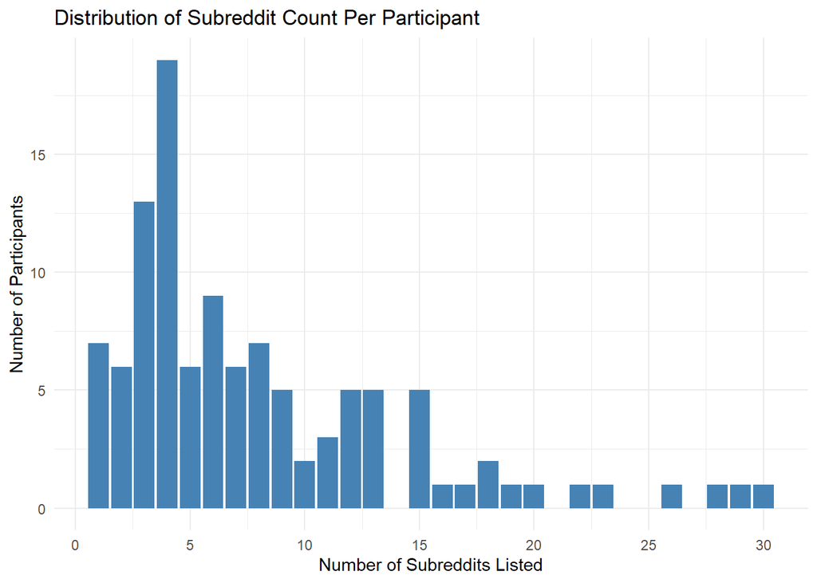

```r
#distribution of subreddits listed per participant
subreddit_count_per_participant <- subreddit_data_categorized %>%
  group_by(Subject) %>%
  summarise(n_subreddits = n())

ggplot(subreddit_count_per_participant, aes(x = n_subreddits)) +
  geom_bar(fill = "steelblue") +
  scale_x_continuous(breaks = seq(0, 30, 5)) +
  labs(
    title = "Distribution of Subreddit Count Per Participant",
    x = "Number of Subreddits Listed",
    y = "Number of Participants") + theme_minimal()
```

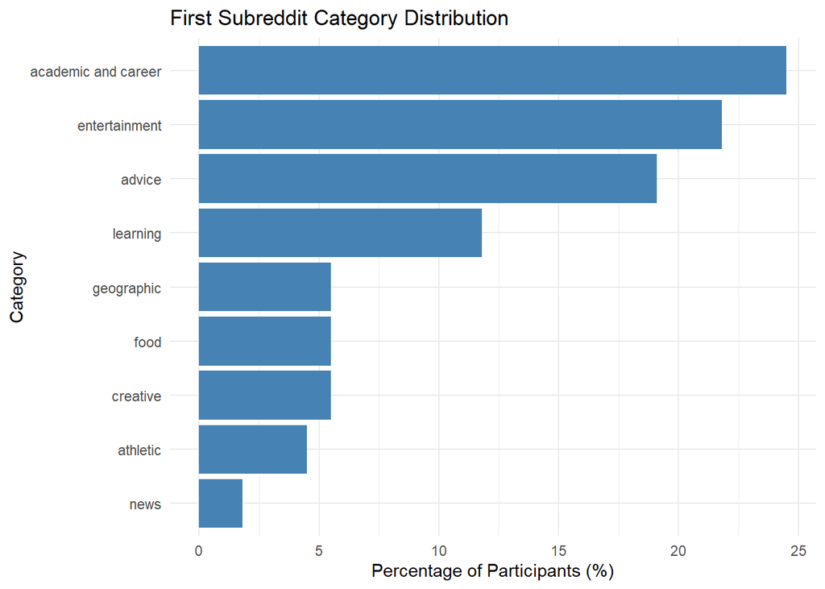

```r
ggsave("subreddit_count_distribution.png", width = 8, height = 5, dpi = 300)


#distribution of primary buckets people's first subreddit input fell into
ggplot(primary_bucket_summary, aes(x = reorder(primary_bucket, pct), y = pct)) +
  geom_col(fill = "steelblue") +
  coord_flip() +
  scale_y_continuous(breaks = seq(0, 30, 5)) +
  labs(
    title = "First Subreddit Category Distribution",
    x = "Category",
    y = "Percentage of Participants (%)"
  ) + theme_minimal()
```

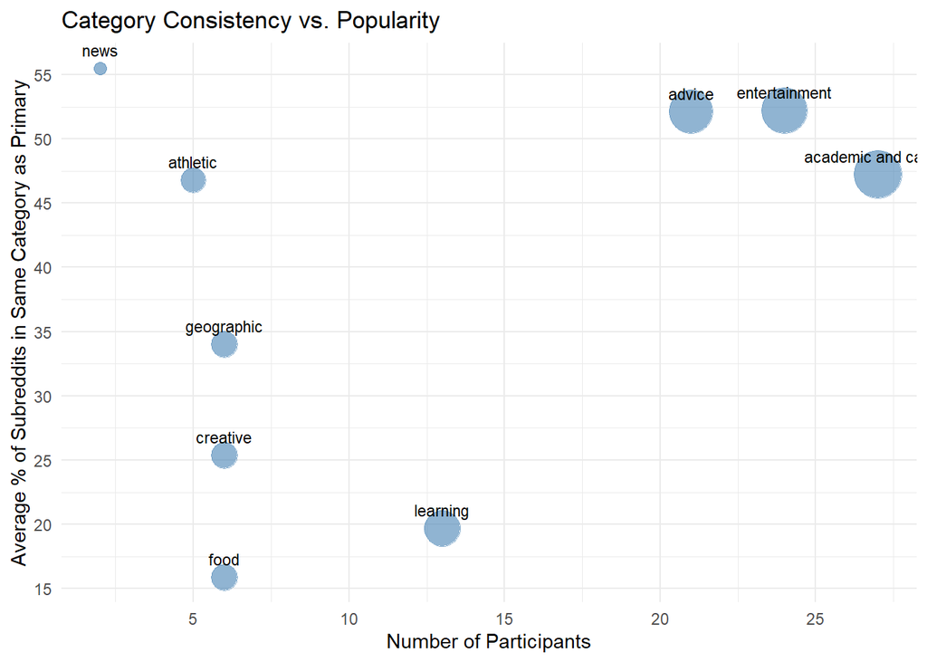

```r
ggsave("primary_bucket_distribution.png", width = 8, height = 5, dpi = 300)

#Participant consistency based on primary bucket
ggplot(participant_consistency_summary, aes(x = n_participants, y = average_pct_match, size = n_participants, label = primary_bucket)) +
  geom_point(alpha = 0.6, color = "steelblue") +
  geom_text(vjust = -1, size = 3) +
  scale_size_continuous(range = c(3, 12)) +
  scale_x_continuous(breaks = seq(0, 30, 5)) +
  scale_y_continuous(breaks = seq(0, 60, 5)) +
  labs(
    title = "Category Consistency vs. Popularity",
    x = "Number of Participants",
    y = "Average % of Subreddits in Same Category as Primary",
    size = "N Participants",
  ) +
  theme_minimal() + theme(legend.position = "none")
```

```r
ggsave("category_consistency_and_popularity.png", width = 8, height = 6, dpi = 300)
```

Exploring subreddits named over time

```r
reddit_raw_data <- read_csv("../Data/raw_data/reddit_data.csv")
```

```r
subreddit_reaction_time <- reddit_raw_data %>%
  filter(task == "VFT", domain == "subreddits") %>%
  select(subject, response_times) %>%

mutate(response_times = str_remove_all(response_times, "\\[|\\]")) %>%
  separate_rows(response_times, sep = ",") %>%
  mutate(response_times = as.numeric(str_trim(response_times))) %>%
  group_by(subject) %>%
  mutate(
    subreddit_number = row_number(),
    cumulative_rt_s = cumsum(response_times) / 1000
  ) %>%
  ungroup()

max_time <- ceiling(max(subreddit_reaction_time$cumulative_rt_s, na.rm = TRUE))

subjects <- unique(subreddit_reaction_time$subject)

cumulative_curve <- tibble(second = 1:max_time) %>%
  mutate(
    avg_subreddits = sapply(second, function(s) {
      mean(sapply(subjects, function(subj) {
        sum(subreddit_reaction_time$cumulative_rt_s[subreddit_reaction_time$subject == subj] <= s, na.rm = TRUE)
      }))
    })
  )

print(cumulative_curve, n = 90)
```

```
## # A tibble: 180 × 2
##    second avg_subreddits
##     <int>          <dbl>
##  1      1         0
##  2      2         0
##  3      3         0.0426
##  4      4         0.0851
##  5      5         0.121
##  6      6         0.191
##  7      7         0.284
##  8      8         0.397
##  9      9         0.489
## 10     10         0.582
## 11     11         0.702
## 12     12         0.816
```

[output cut: 79 more lines]

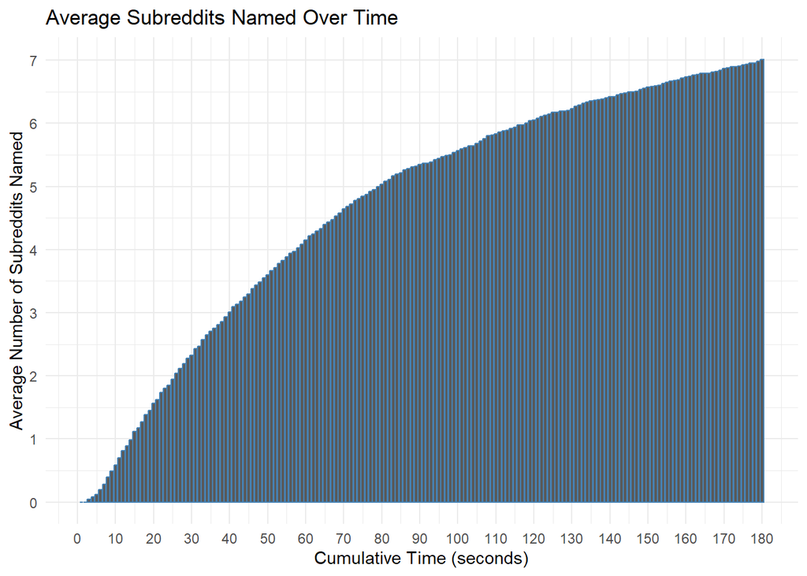

```r
ggplot(cumulative_curve, aes(x = second, y = avg_subreddits)) +
  geom_col(color = "steelblue") +
  scale_x_continuous(breaks = seq(0, max_time, 10)) +
  scale_y_continuous(breaks = seq(0, ceiling(max(cumulative_curve$avg_subreddits)), 1)) +
  labs(
    title = "Average Subreddits Named Over Time",
    x = "Cumulative Time (seconds)",
    y = "Average Number of Subreddits Named"
  ) + theme_minimal()
```

```r
ggsave("average_subreddits_named_over_time.png", width = 8, height = 6, dpi = 300)
```

subreddits named over time (in 30 second intervals)

```r
reddit_raw_data <- read_csv("../Data/raw_data/reddit_data.csv")
```

```r
subreddit_reaction_time <- reddit_raw_data %>%
  filter(task == "VFT", domain == "subreddits") %>%
  select(subject, response_times) %>%

mutate(response_times = str_remove_all(response_times, "\\[|\\]")) %>%
  separate_rows(response_times, sep = ",") %>%
  mutate(response_times = as.numeric(str_trim(response_times))) %>%
  group_by(subject) %>%
  mutate(
    subreddit_number = row_number(),
    cumulative_rt_s = cumsum(response_times) / 1000
  ) %>%
  ungroup()

max_time <- ceiling(max(subreddit_reaction_time$cumulative_rt_s, na.rm = TRUE))

subjects <- unique(subreddit_reaction_time$subject)

number_of_subjects <- length(subjects)

percentage_cumulative_curve <- tibble(second = 1:max_time) %>%
  mutate(
    avg_subreddits = sapply(second, function(s) {
      mean(sapply(subjects, function(subj) {
        sum(subreddit_reaction_time$cumulative_rt_s[subreddit_reaction_time$subject == subj] <= s, na.rm = TRUE)
      }))
    }),
    percent_named_one_subreddit = sapply(second, function(s) {
      100 * mean(sapply(subjects, function(subj) {
        any(subreddit_reaction_time$cumulative_rt_s[subreddit_reaction_time$subject == subj] <= s, na.rm = TRUE)
      }))
    })
  )


cumulative_curve <- tibble(second = 1:max_time) %>%
  mutate(
    avg_subreddits = sapply(second, function(s) {
      mean(sapply(subjects, function(subj) {
        sum(subreddit_reaction_time$cumulative_rt_s[subreddit_reaction_time$subject == subj] <= s, na.rm = TRUE)
      }))
    })
  )

print(cumulative_curve, n = 90)
```

```
## # A tibble: 180 × 2
##    second avg_subreddits
##     <int>          <dbl>
##  1      1         0
##  2      2         0
##  3      3         0.0426
##  4      4         0.0851
##  5      5         0.121
##  6      6         0.191
##  7      7         0.284
##  8      8         0.397
##  9      9         0.489
## 10     10         0.582
## 11     11         0.702
## 12     12         0.816
```

[output cut: 79 more lines]

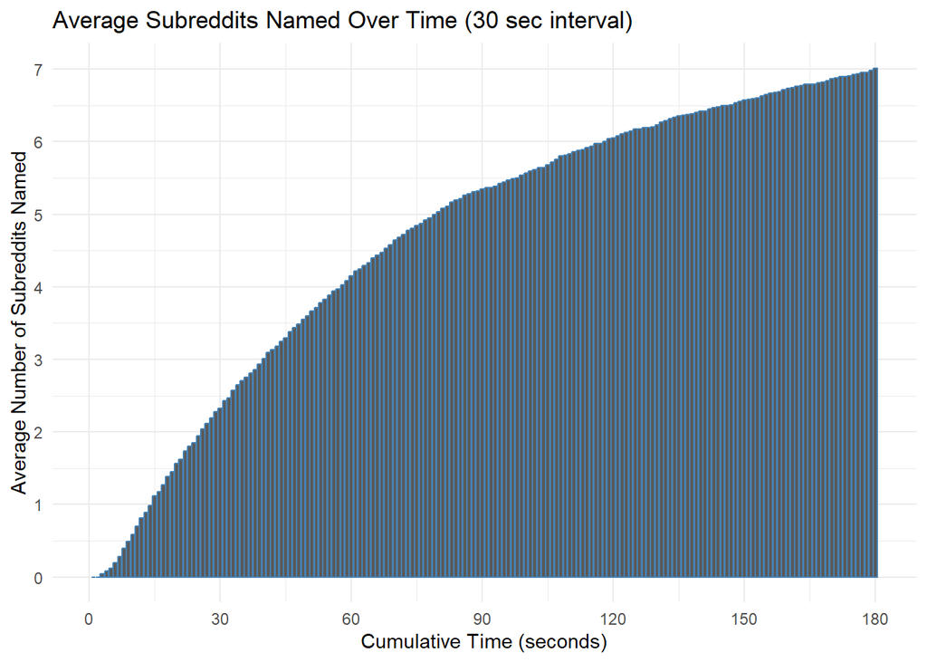

```r
ggplot(cumulative_curve, aes(x = second, y = avg_subreddits)) +
  geom_col(color = "steelblue") +
  scale_x_continuous(breaks = seq(0, max_time, 30)) +
  scale_y_continuous(breaks = seq(0, ceiling(max(cumulative_curve$avg_subreddits)), 1)) +
  labs(
    title = "Average Subreddits Named Over Time (30 sec interval)",
    x = "Cumulative Time (seconds)",
    y = "Average Number of Subreddits Named"
  ) + theme_minimal()
```

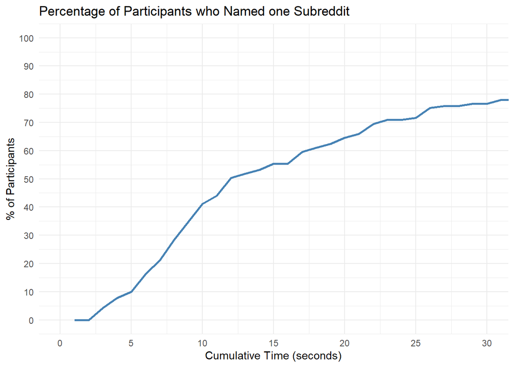

```r
ggsave("average_subreddits_named_over_time_30sec_interval.png", width = 8, height = 6, dpi = 300)

ggplot(percentage_cumulative_curve, aes(x = second, y = percent_named_one_subreddit)) +
  geom_line(color = "steelblue", linewidth = 1) +
  coord_cartesian(xlim = c(0,30)) +
  scale_x_continuous(breaks = seq(0, 30, 5)) +
  scale_y_continuous(breaks = seq(0,100, 10), limits = c(0, 100)) +
  labs(
    title = "Percentage of Participants who Named one Subreddit",
    x = "Cumulative Time (seconds)",
    y = "% of Participants"
  ) + theme_minimal()
```

```r
ggsave("percentage_participants_who_named_subreddit_over_time.png", width = 8, height = 6, dpi = 300)
```

Domain inputs named over time

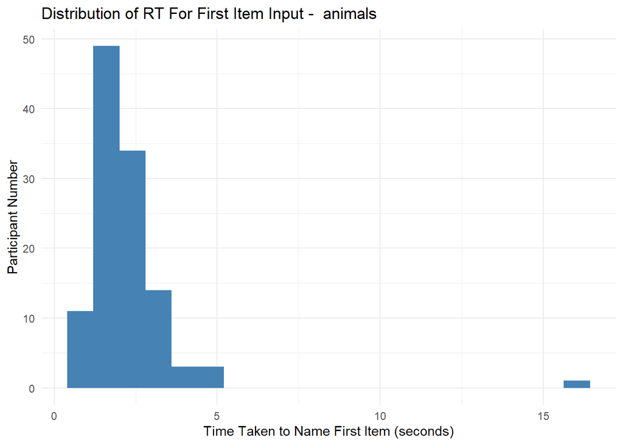

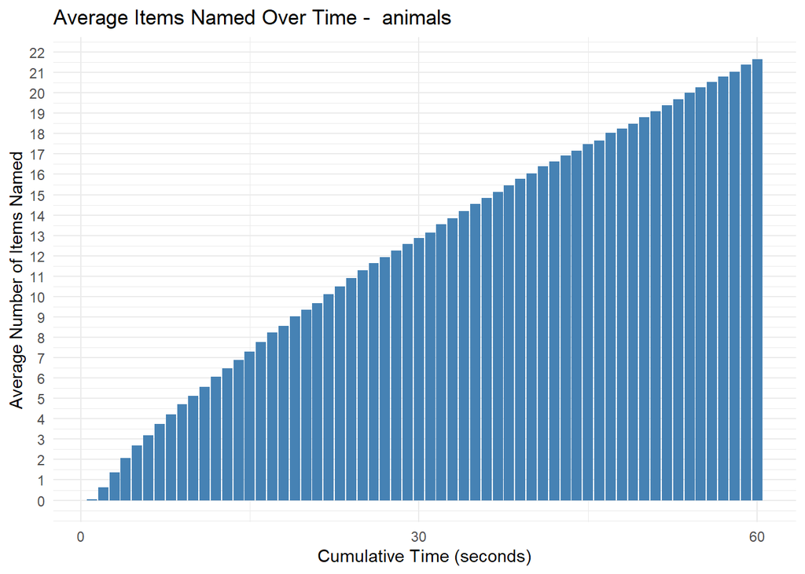

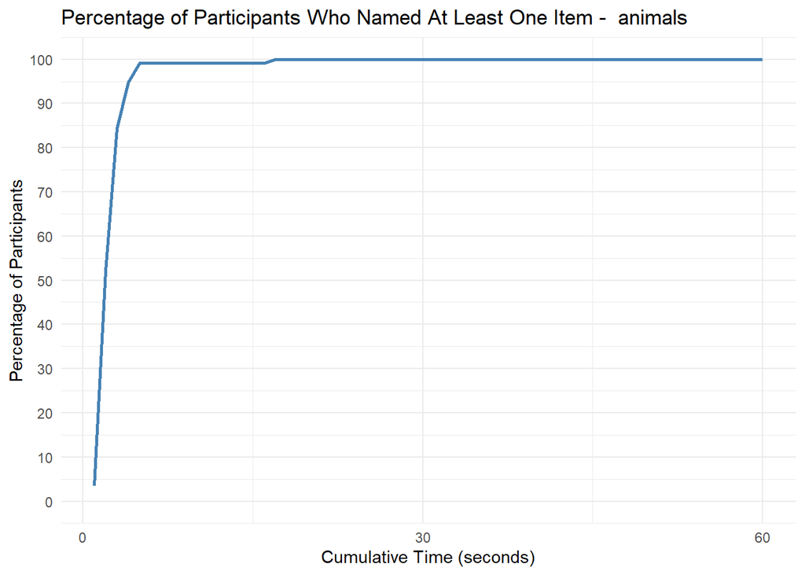

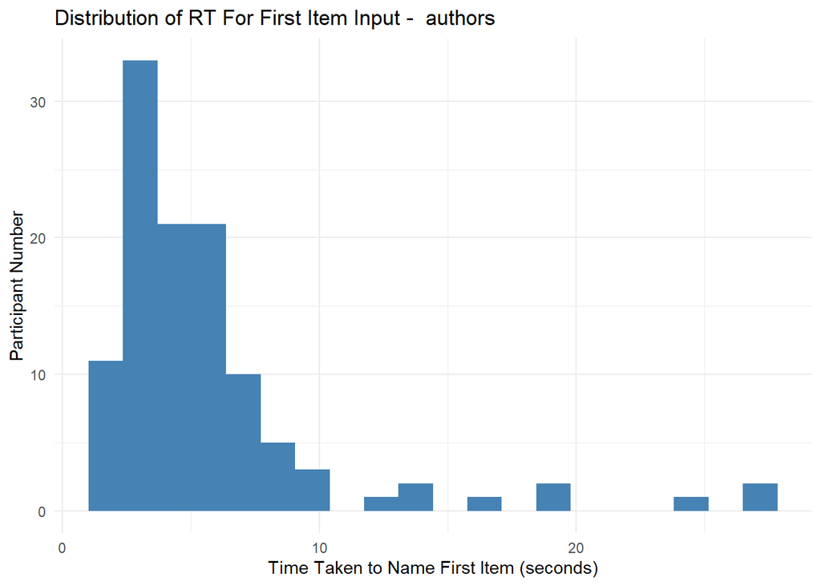

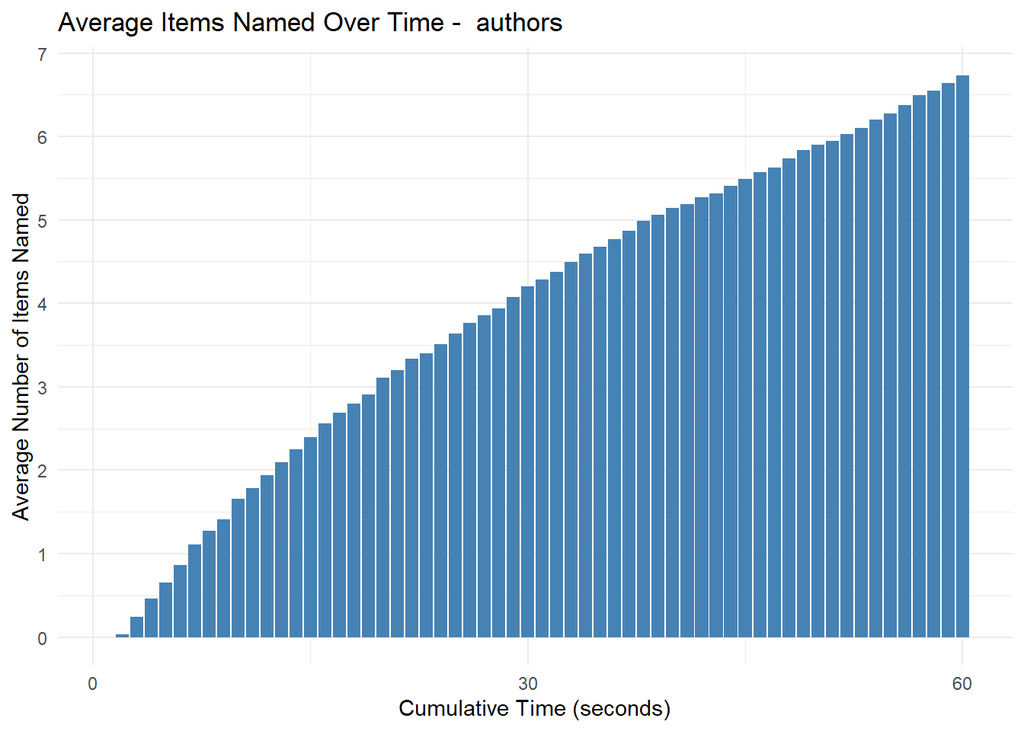

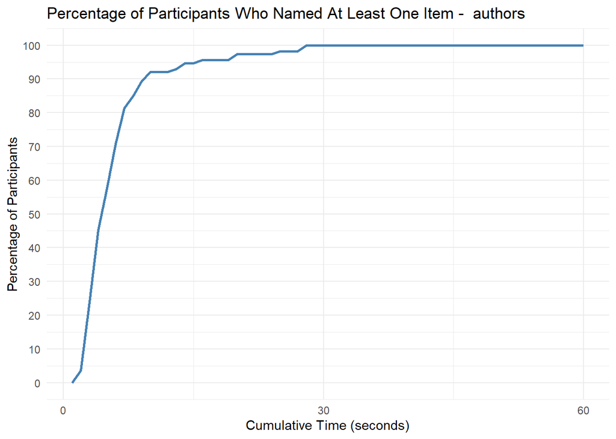

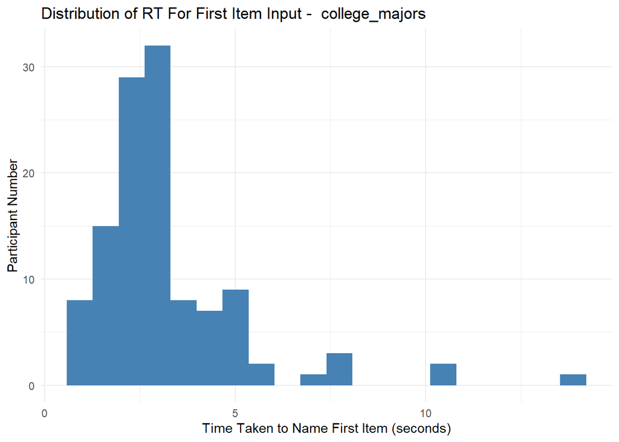

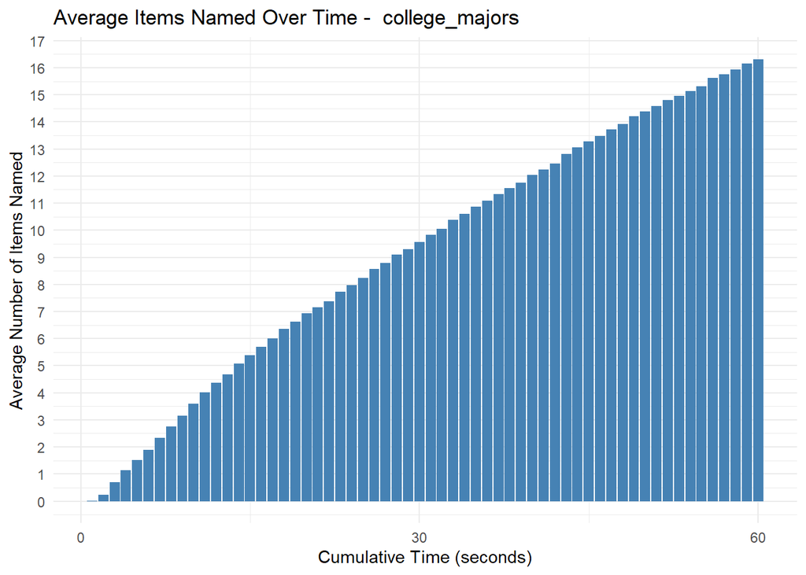

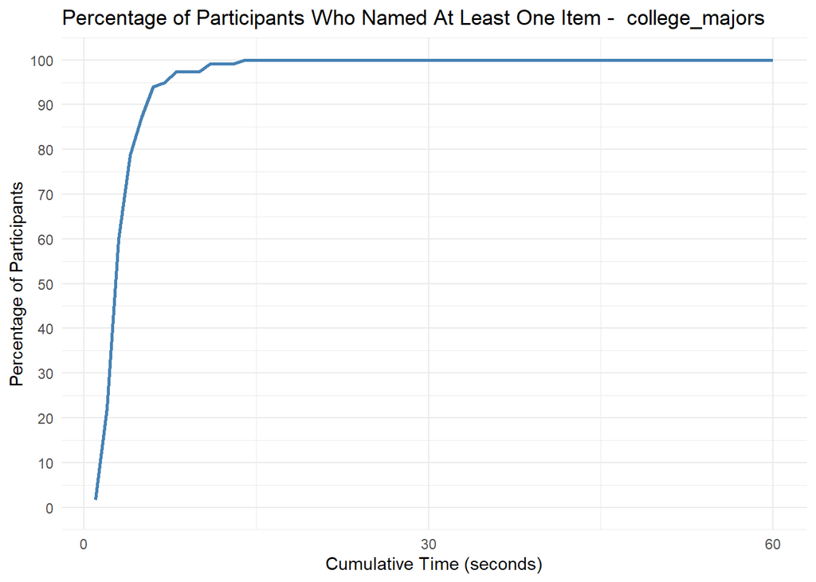

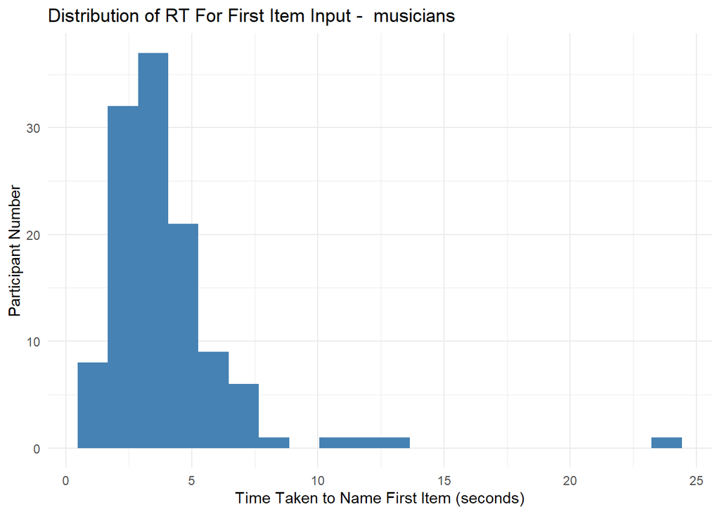

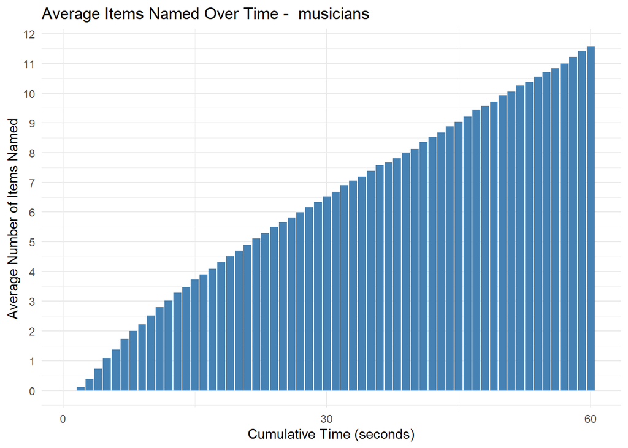

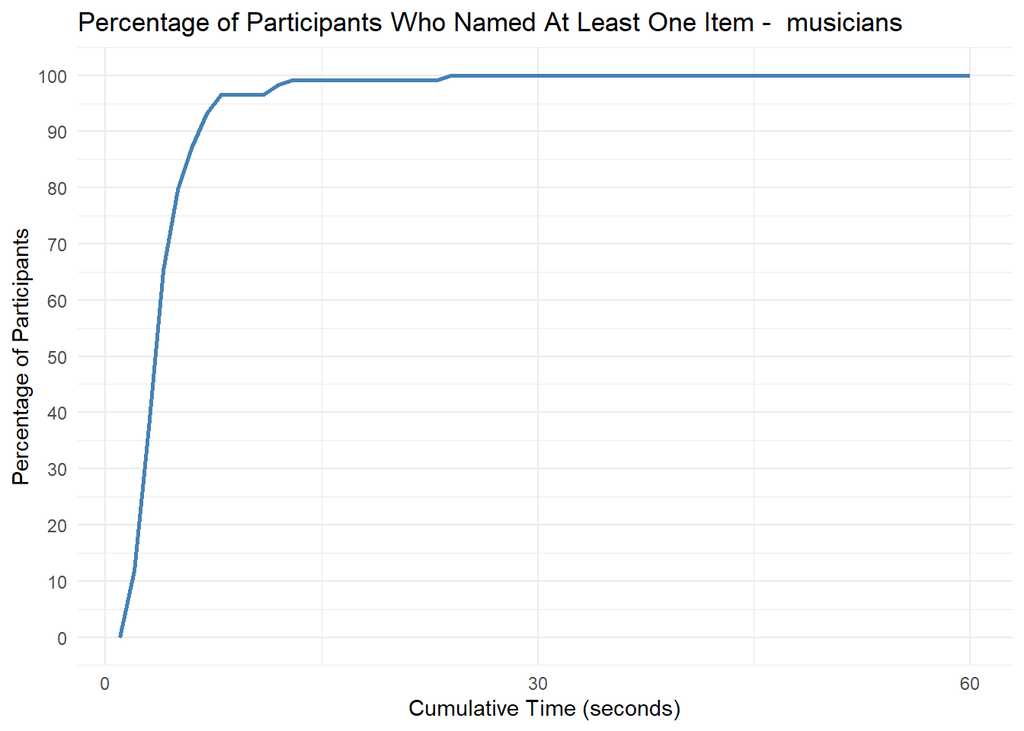

[3 more figures not shown]

```r
fluency_domains <- c("animals", "authors", "college_majors", "musicians", "sportspersons")

for (dom in fluency_domains) {
  fluency_rt <- reddit_raw_data %>%
    filter(task == "VFT", domain == dom) %>%
    select(subject, response_times) %>%
    mutate(response_times = str_remove_all(response_times, "\\[|\\]")) %>%
    separate_rows(response_times, sep = ",") %>%
    mutate(response_times = as.numeric(str_trim(response_times))) %>%
    group_by(subject) %>%
    mutate(item_number = row_number(), cumulative_rt_s = cumsum(response_times) / 1000) %>%
    ungroup()

  max_time <- ceiling(max(fluency_rt$cumulative_rt_s, na.rm = TRUE))
  subjects <- unique(fluency_rt$subject)

  fluency_curve <- tibble(second = 1:max_time) %>%
    mutate(avg_items = sapply(second, function(s) {
      mean(sapply(subjects, function(subj) {
        sum(fluency_rt$cumulative_rt_s[fluency_rt$subject == subj] <= s, na.rm = TRUE)
      }))
    }),
    percent_named_one = sapply(second, function(s) {
      100 * mean(sapply(subjects, function(subj) {
        any(fluency_rt$cumulative_rt_s[fluency_rt$subject == subj] <= s, na.rm = TRUE)
      }))
    }))
  first_item_rt <- fluency_rt %>%
    filter(item_number == 1) %>%
    mutate(first_rt_s = cumulative_rt_s)

  first_item_dist <- ggplot(first_item_rt, aes(x = first_rt_s)) +
    geom_histogram(fill = "steelblue", bins = 20) +
    labs(title = paste("Distribution of RT For First Item Input - ", dom),
         x = "Time Taken to Name First Item (seconds)",
         y = "Participant Number") +
    theme_minimal()
  ggsave(paste0(dom, "first_item_rt_distribution.png"), first_item_dist, width = 8, height = 6, dpi = 300)
  print(first_item_dist)


  avg_items_named_over_time_plot <- ggplot(fluency_curve, aes(x = second, y = avg_items)) +
    geom_col(fill = "steelblue") +
    scale_x_continuous(breaks = seq(0, max_time, 30)) +
    scale_y_continuous(breaks = seq(0, ceiling(max(fluency_curve$avg_items)), 1)) +
    labs(title = paste("Average Items Named Over Time - " , dom),
         x = "Cumulative Time (seconds)",
         y = "Average Number of Items Named") +
    theme_minimal()
    ggsave(paste0(dom, "avg_items_named_over_time_plot.png"), avg_items_named_over_time_plot, width = 8, height = 6, dpi = 300)
  print(avg_items_named_over_time_plot)


  percentage_named_over_time_plot <- ggplot(fluency_curve, aes(x = second, y = percent_named_one)) +
    geom_line(color = "steelblue", linewidth = 1) +
    scale_x_continuous(breaks = seq(0, max_time, 30)) +
    scale_y_continuous(breaks = seq(0, 100, 10), limits = c(0, 100)) +
    labs(title = paste("Percentage of Participants Who Named At Least One Item - " , dom),
         x = "Cumulative Time (seconds)",
         y = "Percentage of Participants") +
    theme_minimal()
    ggsave(paste0(dom, "percentage_named_over_time_plot.png"), percentage_named_over_time_plot, width = 8, height = 6, dpi = 300)
  print(percentage_named_over_time_plot)

}
```

```r
#library(patchwork)
# new_plot <- plot1 + plot2
```

3. Fluency and interest correlations calculated and range box plots (interest and fluency spread) formed

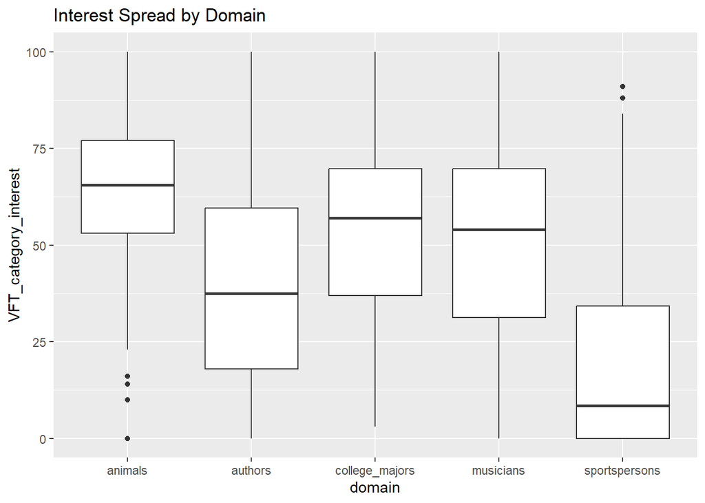

```r
fluency_wide <- read.csv("../Data/cleaned_data/fluency_interest_estimate.csv")%>%
  select(-rt)%>%
  pivot_wider(names_from = typeoftrial, values_from = response)
View(fluency_wide)

#Box plot of interest spread across domains
ggplot(fluency_wide, aes(x = domain, y = VFT_category_interest)) + geom_boxplot() + labs(title = "Interest Spread by Domain")
```

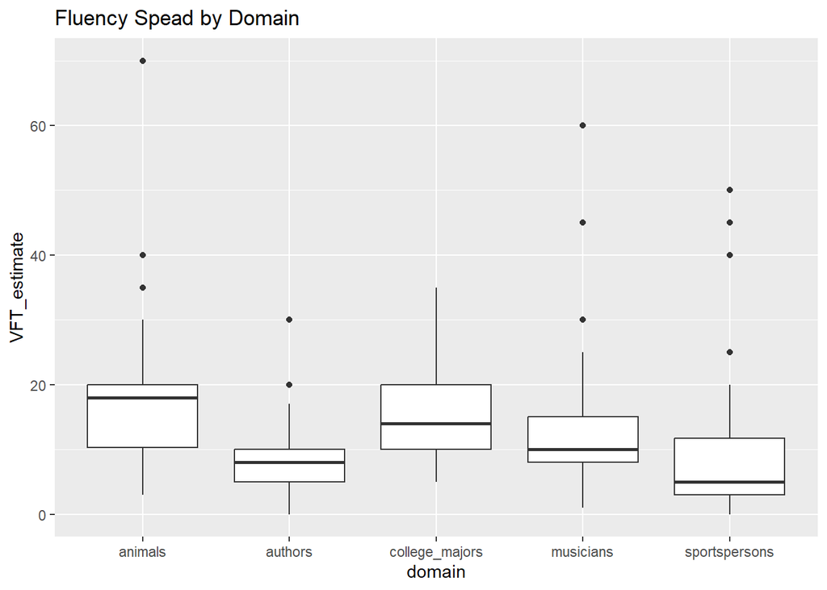

```r
ggsave("interest_spread_by_domain_plot.png", width = 8, height = 6)

#Box plot of fluency spread across domains
ggplot(fluency_wide, aes(x = domain, y = VFT_estimate)) + geom_boxplot() + labs(title = "Fluency Spead by Domain")
```

```r
ggsave("fluency_spread_by_domain_plot.png", width = 8, height = 6)

#Summary of correlation between fluency and interest per domain
fluency_wide %>% group_by(domain) %>% summarize(correlation = cor(VFT_category_interest, VFT_estimate, use = "complete.obs"))
```

```
## # A tibble: 5 × 2
##   domain         correlation
##   <chr>                <dbl>
## 1 animals              0.175
## 2 authors              0.344
## 3 college_majors       0.117
## 4 musicians            0.372
## 5 sportspersons        0.706
```

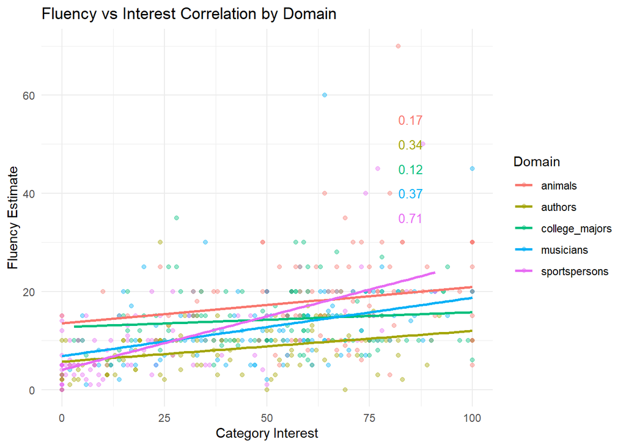

```r
#Plot of correlation, annotated ^
correlation_labels <- fluency_wide %>%
  group_by(domain) %>%
  summarize(correlation = round(cor(VFT_category_interest, VFT_estimate, use = "complete.obs"), 2), x = 85, y = max(VFT_estimate, na.rm = TRUE) * 0.9)
correlation_labels$y <- c(55, 50, 45, 40, 35)

ggplot(fluency_wide, aes(x = VFT_category_interest, y = VFT_estimate, color = domain)) + geom_point(alpha = 0.4) + geom_smooth(method = "lm", se = FALSE) + geom_text(
  data = correlation_labels, aes(x = x, y = y, label = paste0("r" = correlation), color = domain), show.legend = FALSE, size = 3.5) +
  labs(title = "Fluency vs Interest Correlation by Domain", x = "Category Interest", y = "Fluency Estimate", color = "Domain") + theme_minimal()
```

```r
ggsave("fluency_interest_by_domain_correlation_plot.png", width = 8, height = 6)
```

Interest domain split and phonological/semantic similarity + frequency

```r
interest_data <- read_csv("../Data/cleaned_data/fluency_interest_estimate.csv")
interest_rating <- interest_data %>%
  dplyr::filter(typeoftrial == "VFT_category_interest") %>%
  select(subject, domain, interest_value = response)

#interest_rating %>%
#  group_by(domain) %>%
#  summarise(median = median(interest_value), mean = mean(interest_value))

interest_groups <- interest_rating %>%
  group_by(domain) %>%
  mutate(
    median_interest = median(interest_value, na.rm = TRUE),
    interest_group = if_else(interest_value >= median_interest, "high_interest", "low_interest")
  ) %>%
  ungroup() %>%
  select(subject, domain, interest_value, interest_group)

lexical_domain_interest_groups <- all_lexical_results %>%
  left_join(interest_groups, by = c("Subject" = "subject", "domain" = "domain")) %>%
  dplyr::filter(!is.na(interest_group))

lexical_domain_interest_summary <- lexical_domain_interest_groups %>%
  group_by(domain, interest_group) %>%
  summarise(
    mean_semantic_similarity = mean(Semantic_Similarity, na.rm = TRUE),
    mean_phonological_similarity = mean(Phonological_Similarity, na.rm = TRUE),
    mean_frequency = mean(Frequency_Value, na.rm = TRUE),
    .groups = "drop"
  )

subject_summary <- lexical_domain_interest_groups %>%
  group_by(Subject, domain, interest_group) %>%
  summarise(
    semantic_similarity = mean(Semantic_Similarity, na.rm = TRUE),
    phonological_similarity = mean(Phonological_Similarity, na.rm = TRUE),
    frequency = mean(Frequency_Value, na.rm = TRUE),
    .groups = "drop"
  )

subject_level_interest_summary <- subject_summary %>%
  group_by(domain, interest_group) %>%
  summarize(
    mean_semantic_similarity = mean(semantic_similarity, na.rm = TRUE),
    mean_phonological_similarity = mean(phonological_similarity, na.rm = TRUE),
    mean_frequency = mean(frequency, na.rm = TRUE),
    .groups = "drop"
  )

print(lexical_domain_interest_summary)
```

```
## # A tibble: 10 × 5
##    domain         interest_group mean_semantic_similarity mean_phonological_si…¹
##    <chr>          <chr>                             <dbl>                  <dbl>
##  1 animals        high_interest                     0.403                 0.0749
##  2 animals        low_interest                      0.411                 0.0742
##  3 authors        high_interest                     0.262                 0.0761
##  4 authors        low_interest                      0.263                 0.0762
##  5 college_majors high_interest                     0.387                 0.116
##  6 college_majors low_interest                      0.375                 0.119
##  7 musicians      high_interest                     0.285                 0.0759
##  8 musicians      low_interest                      0.290                 0.0753
##  9 sportspersons  high_interest                     0.299                 0.0861
## 10 sportspersons  low_interest                      0.278                 0.0769
## # ℹ abbreviated name: ¹mean_phonological_similarity
## # ℹ 1 more variable: mean_frequency <dbl>
```

```r
print(subject_level_interest_summary)
```

```
## # A tibble: 10 × 5
##    domain         interest_group mean_semantic_similarity mean_phonological_si…¹
##    <chr>          <chr>                             <dbl>                  <dbl>
##  1 animals        high_interest                     0.399                 0.0760
##  2 animals        low_interest                      0.408                 0.0727
##  3 authors        high_interest                     0.232                 0.0649
##  4 authors        low_interest                      0.234                 0.0667
##  5 college_majors high_interest                     0.383                 0.115
##  6 college_majors low_interest                      0.372                 0.118
##  7 musicians      high_interest                     0.280                 0.0744
##  8 musicians      low_interest                      0.281                 0.0693
##  9 sportspersons  high_interest                     0.271                 0.0780
## 10 sportspersons  low_interest                      0.253                 0.0696
## # ℹ abbreviated name: ¹mean_phonological_similarity
## # ℹ 1 more variable: mean_frequency <dbl>
```

Plots

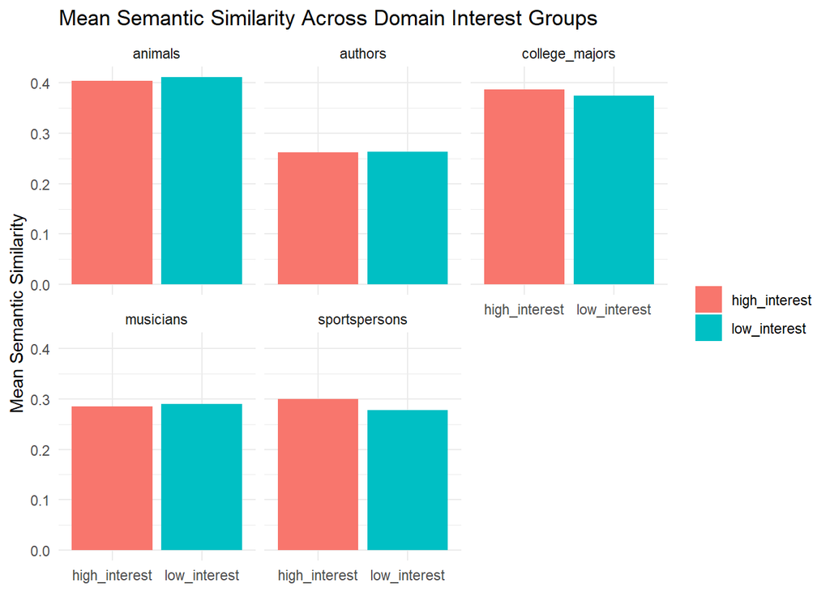

```r
#Plotting semantic similarity across groups
ggplot(lexical_domain_interest_summary, aes(x = interest_group, y = mean_semantic_similarity, fill = interest_group)) +
  geom_col() +
  facet_wrap(~ domain) +
  labs(title = "Mean Semantic Similarity Across Domain Interest Groups", x = NULL, y = "Mean Semantic Similarity") +
  theme_minimal() +
  theme(legend.title = element_blank())
```

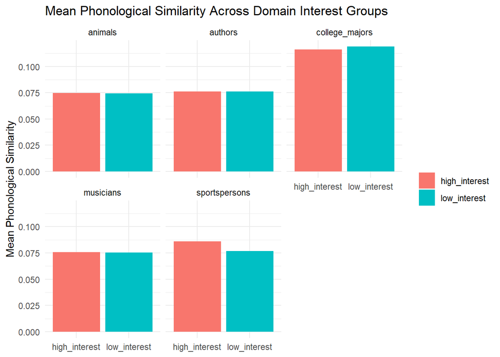

```r
ggsave("semantic_similarity_across_domain_interest.png", width = 8, height = 5, dpi = 300)


#Plotting phonological similarity across groups
ggplot(lexical_domain_interest_summary, aes(x = interest_group, y = mean_phonological_similarity, fill = interest_group)) +
  geom_col() +
  facet_wrap(~ domain) +
  labs(title = "Mean Phonological Similarity Across Domain Interest Groups", x = NULL, y = "Mean Phonological Similarity") +
  theme_minimal() +
  theme(legend.title = element_blank())
```

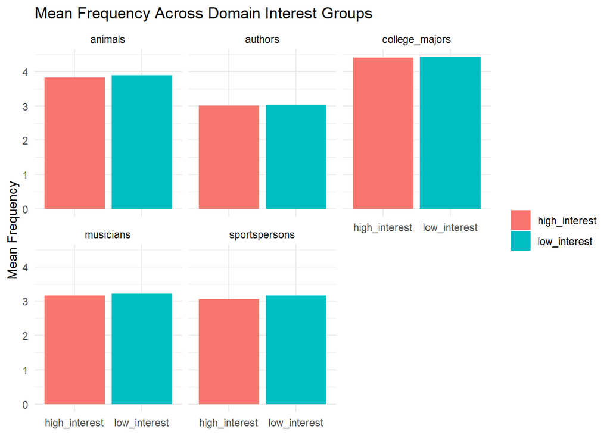

```r
ggsave("phonological_similarity_across_domain_interest.png", width = 8, height = 5, dpi = 300)


#Plotting frequency across groups
ggplot(lexical_domain_interest_summary, aes(x = interest_group, y = mean_frequency, fill = interest_group)) +
  geom_col() +
  facet_wrap(~ domain) +
  labs(title = "Mean Frequency Across Domain Interest Groups", x = NULL, y = "Mean Frequency") +
  theme_minimal() +
  theme(legend.title = element_blank())
```

```r
ggsave("frequency_across_domain_interest.png", width = 8, height = 5, dpi = 300)
```

Prediction vs Actual Fluency Regression

```r
#Reading in fluency data
fluency_data <- read_csv("../Data/cleaned_data/fluency_data.csv")
#Calculating the number of fluency responses per participant per domain
fluency_number = fluency_data %>%
  group_by(Subject, domain) %>%
  summarise(
    fluency_number = n(),
    .groups = "drop"
  )

#Reading in predicted fluency estimate
fluency_wide <- read.csv("../Data/cleaned_data/fluency_interest_estimate.csv")%>%
  select(-rt)%>%
  pivot_wider(names_from = typeoftrial, values_from = response)
View(fluency_wide)

#Combining actual and estimated fluency
fluency_regression <- fluency_wide %>%
  left_join(fluency_number, by = c("subject" = "Subject", "domain"))
View(fluency_regression)

fluency_regression_model <- lm(fluency_number ~ VFT_estimate, data = fluency_regression)
summary(fluency_regression_model)
```

```
##
## Call:
## lm(formula = fluency_number ~ VFT_estimate, data = fluency_regression)
##
## Residuals:
##      Min       1Q   Median       3Q      Max
## -23.5283  -3.5890  -0.8196   3.4110  15.6395
##
## Coefficients:
##              Estimate Std. Error t value Pr(>|t|)
## (Intercept)   6.20111    0.39664   15.63   <2e-16 ***
## VFT_estimate  0.53879    0.02645   20.37   <2e-16 ***
## ---
## Signif. codes:  0 '***' 0.001 '**' 0.01 '*' 0.05 '.' 0.1 ' ' 1
##
## Residual standard error: 5.149 on 548 degrees of freedom
## Multiple R-squared:  0.4308, Adjusted R-squared:  0.4298
## F-statistic: 414.8 on 1 and 548 DF,  p-value: < 2.2e-16
```

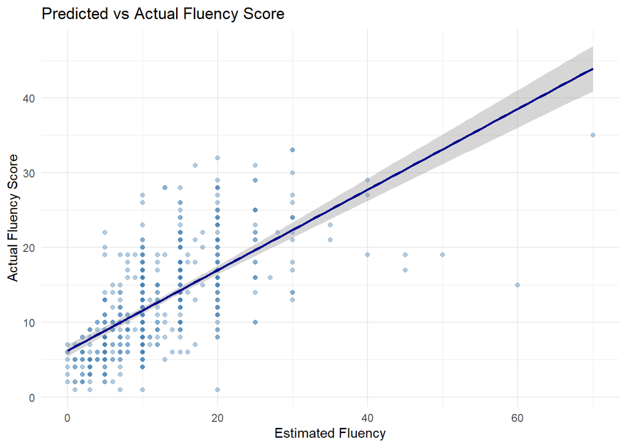

```r
ggplot(fluency_regression, aes(x = VFT_estimate, y = fluency_number)) +
  geom_point(alpha = 0.4, color = "steelblue") +
  geom_smooth(method = "lm", color = "darkblue", se = TRUE) +
  labs(title = "Predicted vs Actual Fluency Score",
       x = "Estimated Fluency",
       y = "Actual Fluency Score") +
  theme_minimal()
```

```r
ggsave("fluency_prediction_regression.png", width = 8, heigh = 6, dpi = 300)
```

Semantic Similarity vs Fluency Regression

```r
#lexical cue differences across domains
# linear mixed model
#library(lme4)
#lexical_raw_results <- lexical_analysis_data  %>%
#  group_by(cue) %>%
 # nest() %>%
 #mutate(model = map(data, ~ lmer(value ~ domain + (1|gameId), data = .x)),
 #   emmeans = map(model, ~ emmeans(.x, ~ domain,pbkrtest.limit = 6944)),
 #   contrasts = map(emmeans,~ pairs(.x, adjust = "holm")),
 #   tidy_contrasts = map(contrasts, broom::tidy)) %>%
 # select(cue, tidy_contrasts) %>%
 # unnest(tidy_contrasts) %>%
#  mutate(adj.p.value = round(adj.p.value, 3))


#does lexical cue value predict fluency score
#lexical_models <- lexical_analysis_data %>%
#  group_by(domain, cue) %>%
#  nest() %>%
#  mutate( model = map(data, ~ lm(fluency_score ~ value, data = .)))


#Creating semantic similarity avgs
semantic_summary <- all_lexical_results %>%
  group_by(Subject, domain) %>%
  summarise(mean_semantic = mean(Semantic_Similarity, na.rm = TRUE), .groups = "drop")

#Combining with fluency
semantic_sum_fluency_df <- fluency_number %>%
  left_join(semantic_summary, by = c("Subject", "domain"))

#Regression model
semantic_regression_model <- lm(fluency_number ~ mean_semantic, data = semantic_sum_fluency_df)
summary(semantic_regression_model)
```

```
##
## Call:
## lm(formula = fluency_number ~ mean_semantic, data = semantic_sum_fluency_df)
##
## Residuals:
##      Min       1Q   Median       3Q      Max
## -16.2257  -3.6085  -0.2438   3.1293  17.7169
##
## Coefficients:
##               Estimate Std. Error t value Pr(>|t|)
## (Intercept)    -1.1198     0.7528  -1.487    0.137
## mean_semantic  45.1893     2.3070  19.588   <2e-16 ***
## ---
## Signif. codes:  0 '***' 0.001 '**' 0.01 '*' 0.05 '.' 0.1 ' ' 1
##
## Residual standard error: 5.219 on 546 degrees of freedom
##   (3 observations deleted due to missingness)
## Multiple R-squared:  0.4127, Adjusted R-squared:  0.4116
## F-statistic: 383.7 on 1 and 546 DF,  p-value: < 2.2e-16
```

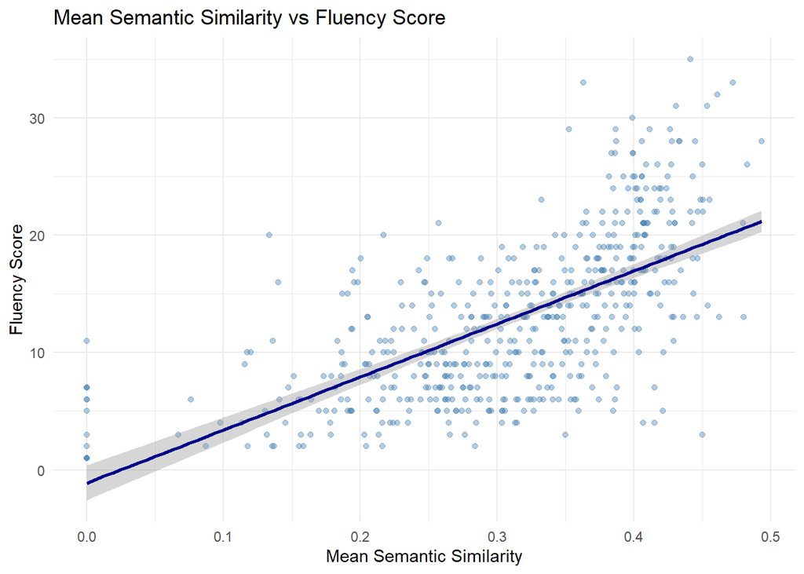

```r
ggplot(semantic_sum_fluency_df, aes(x = mean_semantic, y = fluency_number)) +
  geom_point(alpha = 0.4, color = "steelblue") +
  geom_smooth(method = "lm", color = "darkblue", se = TRUE) +
  labs(title = "Mean Semantic Similarity vs Fluency Score",
       x = "Mean Semantic Similarity",
       y = "Fluency Score") +
  theme_minimal()
```

```r
ggsave("semantic_fluency_regression.png", width = 8, heigh = 6, dpi = 300)
```

Phonological Similarity vs Fluency Regression

```r
#Creating phonological similarity avgs
phonological_summary <- all_lexical_results %>%
  group_by(Subject, domain) %>%
  summarise(
    mean_phonological = mean(Phonological_Similarity, na.rm = TRUE), .groups = "drop"
  )

#Combining with fluency
phonological_sum_fluency_df <- fluency_number %>%
  left_join(phonological_summary, by = c("Subject", "domain"))

#Regression model
phonological_regression_model <- lm(fluency_number ~ mean_phonological, data = phonological_sum_fluency_df)
summary(phonological_regression_model)
```

```
##
## Call:
## lm(formula = fluency_number ~ mean_phonological, data = phonological_sum_fluency_df)
##
## Residuals:
##      Min       1Q   Median       3Q      Max
## -14.3082  -5.1022  -0.9324   3.7632  22.5065
##
## Coefficients:
##                   Estimate Std. Error t value Pr(>|t|)
## (Intercept)         9.5187     0.6418  14.831  < 2e-16 ***
## mean_phonological  42.8380     7.1672   5.977 4.11e-09 ***
## ---
## Signif. codes:  0 '***' 0.001 '**' 0.01 '*' 0.05 '.' 0.1 ' ' 1
##
## Residual standard error: 6.597 on 546 degrees of freedom
##   (3 observations deleted due to missingness)
## Multiple R-squared:  0.06141,    Adjusted R-squared:  0.05969
## F-statistic: 35.72 on 1 and 546 DF,  p-value: 4.108e-09
```

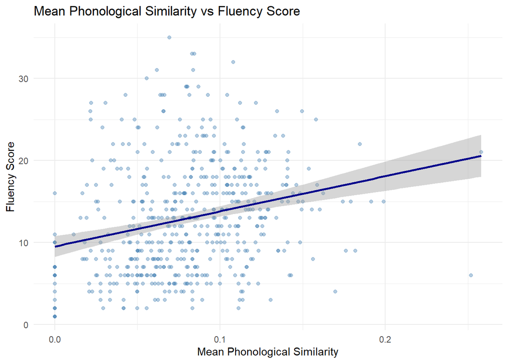

```r
ggplot(phonological_sum_fluency_df, aes(x = mean_phonological, y = fluency_number)) +
  geom_point(alpha = 0.4, color = "steelblue") +
  geom_smooth(method = "lm", color = "darkblue", se = TRUE) +
  labs(title = "Mean Phonological Similarity vs Fluency Score",
       x = "Mean Phonological Similarity",
       y = "Fluency Score") +
  theme_minimal()
```

```r
ggsave("phonological_fluency_regression.png", width = 8, heigh = 6, dpi = 300)
```

_________________________________________________________________________________________________________________________________- EXTRA TESTS + FORAGER PREP

Extra tests (1): Is there a connection between the variety of subreddit categories a person engaged with and their fluency?

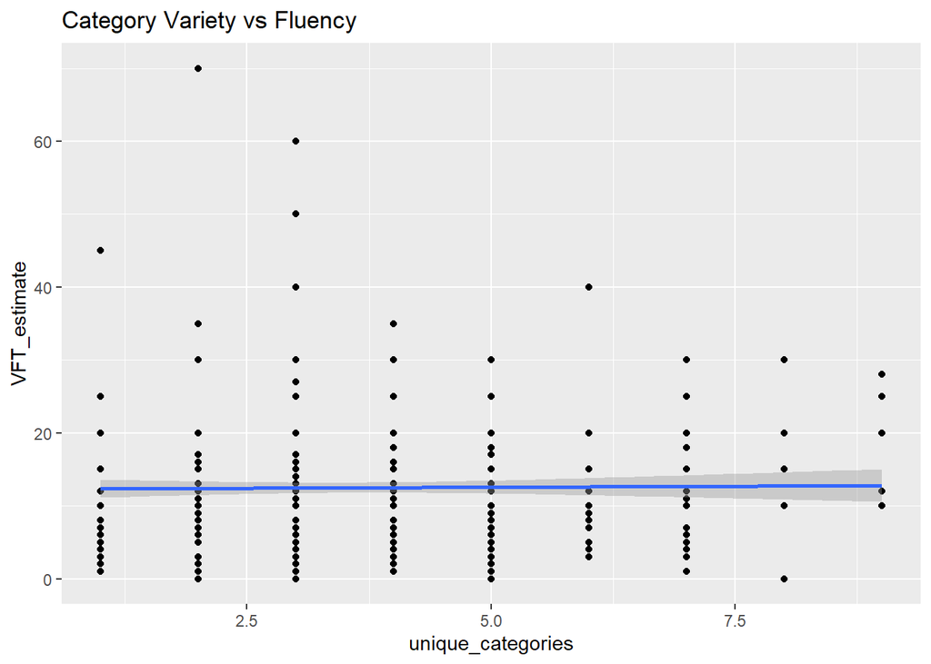

```r
subreddit_variety_data <- subreddit_data_categorized %>%
  group_by(Subject) %>%
  summarize(unique_categories = n_distinct(category, na.rm = TRUE)) %>%
  left_join(fluency_wide, by = c("Subject" = "subject"))

ggplot(subreddit_variety_data, aes(x = unique_categories, y = VFT_estimate)) + geom_point() + geom_smooth(method = "lm") + labs(title = "Category Variety vs Fluency")
```

```r
cor(subreddit_variety_data$unique_categories, subreddit_variety_data$VFT_estimate, use = "complete.obs")
```

```
## [1] 0.01166329
```

Extra tests (2): Do fluency scores differ by language exposure group?

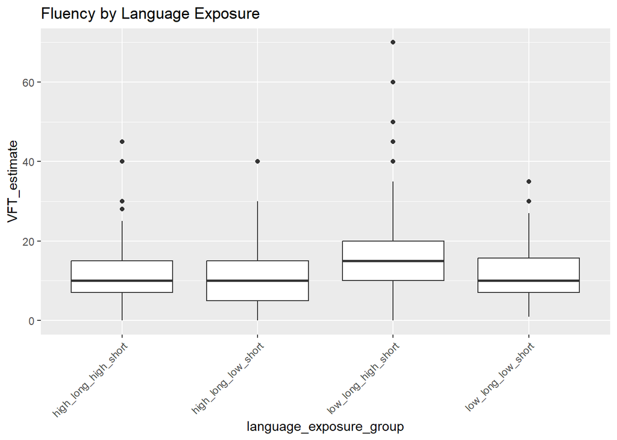

```r
exposure_data <- demographics %>%
  left_join(fluency_wide, by = "subject")

ggplot(exposure_data, aes(x = language_exposure_group, y = VFT_estimate)) + geom_boxplot() + theme(axis.text.x = element_text(angle = 45, hjust = 1)) + labs(title = "Fluency by Language Exposure")
```

```r
#ANOVA testing if fluency differs across exposure, at least one group has a different mean fluency than the others
summary(aov(VFT_estimate ~ language_exposure_group, data = exposure_data))
```

```
##                          Df Sum Sq Mean Sq F value  Pr(>F)
## language_exposure_group   3   1141   380.3   5.652 0.00081 ***
## Residuals               546  36741    67.3
## ---
## Signif. codes:  0 '***' 0.001 '**' 0.01 '*' 0.05 '.' 0.1 ' ' 1
```

```r
#Tukey's test, reveling significant difference between low long, high short and other groups in fluency production
TukeyHSD(aov(VFT_estimate ~ language_exposure_group, data = exposure_data))
```

```
##   Tukey multiple comparisons of means
##     95% family-wise confidence level
##
## Fit: aov(formula = VFT_estimate ~ language_exposure_group, data = exposure_data)
##
## $language_exposure_group
##                                                diff        lwr        upr
## high_long_low_short-high_long_high_short -0.4375576 -2.9022641  2.0271489
## low_long_high_short-high_long_high_short  3.3558710  0.8146511  5.8970908
## low_long_low_short-high_long_high_short   0.5069479 -2.0070736  3.0209693
## low_long_high_short-high_long_low_short   3.7934286  1.1921433  6.3947139
## low_long_low_short-high_long_low_short    0.9445055 -1.6302160  3.5192270
## low_long_low_short-low_long_high_short   -2.8489231 -5.4969810 -0.2008651
##                                              p adj
## high_long_low_short-high_long_high_short 0.9681538
## low_long_high_short-high_long_high_short 0.0039775
## low_long_low_short-high_long_high_short  0.9543666
## low_long_high_short-high_long_low_short  0.0010859
## low_long_low_short-high_long_low_short   0.7803662
## low_long_low_short-low_long_high_short   0.0292976
```